# QTM 151 - Quiz 2

## Try to submit as an HTML file

Print your name below

```python
# Write your answer here

print("Sean Baik")
```

```
Sean Baik
```

This quiz is open book

- You can use the lecture notes
- You will get partial credit for attempting the questions
- To get full credit, the code should run as intended
- You should NOT communicate with other students

Print the following message:

"I will abide by Emory's code of conduct"

```python
# Write your answer here:

print("I will abide by Emory's code of conduct")
```

```
I will abide by Emory's code of conduct
```

Import the libraries "numpy", "matplotlib.pyplot",  
"pandas", "statsmodels.api" and "statsmodels.formula.api"

```python
# Write your answer here

import numpy as np
import matplotlib.pyplot as plt
import pandas as pd
import statsmodels.api as sm
import statsmodels.formula.api as smf
```

Read the dataset "data_quiz/fifa23_players_basic.csv"

- It's a dataset on professional soccer players
- Rows correspond to players (18,539)
- Columns contain attributes of players (32)
- Try to view the dataset before starting  
  to get a sense of its content

```python
# Write your own code

fifa = pd.read_csv("data_quiz/fifa23_players_basic.csv")
```

(a) Use queries + global variables

- Subset the players whose value of the column "On Loan" is "YES"  
  and store it in a new dataset
- How many players are on loan?

HINT: Remember that there is a special syntax for  
when the column names have spaces (see Lecture 10)  
and when the value is a string.  
Reference the column as `` `On Loan` `` inside .query()

```python
# Write your own code

list_loan_condition = pd.unique(fifa["On Loan"])

for category in list_loan_condition:
    df = fifa.query("`On Loan` == @category")

display(df)
```

|  | Unnamed: 0 | Known As | Full Name | Overall | Potential | Value(in Euro) | Positions Played | Best Position | Nationality | Image Link | ... | Preferred Foot | Weak Foot Rating | Skill Moves | International Reputation | National Team Name | National Team Image Link | National Team Position | National Team Jersey Number | Attacking Work Rate | Defensive Work Rate |
| --- | --- | --- | --- | --- | --- | --- | --- | --- | --- | --- | --- | --- | --- | --- | --- | --- | --- | --- | --- | --- | --- |
| 45 | 45 | R. Lukaku | Romelu Lukaku | 86 | 86 | 68000000 | ST | ST | Belgium | https://cdn.sofifa.net/players/192/505/23_60.png | ... | Left | 4 | 3 | 4 | Belgium | https://cdn.sofifa.net/flags/be.png | ST | 9 | Medium | Low |
| 154 | 154 | Angeliño | José Ángel Esmoris Tasende | 83 | 85 | 42000000 | LWB,LM | LM | Spain | https://cdn.sofifa.net/players/220/651/23_60.png | ... | Left | 3 | 4 | 2 | - | https://cdn.sofifa.net/flags/es.png | - | - | High | High |
| 191 | 191 | A. Griezmann | Antoine Griezmann | 83 | 83 | 30500000 | ST,CF,RW | CAM | France | https://cdn.sofifa.net/players/194/765/23_60.png | ... | Left | 3 | 4 | 4 | France | https://cdn.sofifa.net/flags/fr.png | CAM | 7 | Medium | Medium |
| 204 | 204 | M. Locatelli | Manuel Locatelli | 82 | 86 | 40000000 | CDM,CM | CM | Italy | https://cdn.sofifa.net/players/222/077/23_60.png | ... | Right | 4 | 3 | 2 | Italy | https://cdn.sofifa.net/flags/it.png | SUB | 5 | Medium | High |
| 205 | 205 | R. Gosens | Robin Gosens | 82 | 82 | 29500000 | LWB,LM | LWB | Germany | https://cdn.sofifa.net/players/223/697/23_60.png | ... | Left | 3 | 3 | 3 | Germany | https://cdn.sofifa.net/flags/de.png | SUB | 16 | High | Medium |
| ... | ... | ... | ... | ... | ... | ... | ... | ... | ... | ... | ... | ... | ... | ... | ... | ... | ... | ... | ... | ... | ... |
| 18206 | 18206 | Kim Jeong hoon | Jeong Hoon Kim | 52 | 62 | 160000 | GK | GK | Korea Republic | https://cdn.sofifa.net/players/252/662/23_60.png | ... | Right | 2 | 1 | 1 | - | - | - | - | Medium | Medium |
| 18283 | 18283 | E. Taylor | Ellis Taylor | 51 | 65 | 140000 | RM,LB | LM | England | https://cdn.sofifa.net/players/263/990/23_60.png | ... | Left | 3 | 2 | 1 | - | https://cdn.sofifa.net/flags/gb-eng.png | - | - | Medium | Medium |
| 18343 | 18343 | Yoon Suk Ju | Suk Ju Yoon | 50 | 65 | 110000 | CDM | CDM | Korea Republic | https://cdn.sofifa.net/players/261/121/23_60.png | ... | Right | 3 | 2 | 1 | - | - | - | - | Medium | Medium |
| 18390 | 18390 | S. Ghidotti | Simone Ghidotti | 50 | 57 | 80000 | GK | GK | Italy | https://cdn.sofifa.net/players/270/756/23_60.png | ... | Right | 1 | 1 | 1 | - | https://cdn.sofifa.net/flags/it.png | - | - | Medium | Medium |
| 18431 | 18431 | D. Robson | David Robson | 50 | 63 | 100000 | GK | GK | Wales | https://cdn.sofifa.net/players/258/888/23_60.png | ... | Right | 2 | 1 | 1 | - | https://cdn.sofifa.net/flags/gb-wls.png | - | - | Medium | Medium |

1229 rows × 33 columns

(b) Create a function and apply it to a column

Step 1:

- Define a function with a parameter "Overall"
- If "Overall > 90", classification = "Top Performer"
- If "Overall <= 90", classification = "Non Top-Performer"
- The function returns "classification"

Step 2:

- Extract the column "Overall" in the dataset  
  (be carefeful to write the "O" capitalized)
- Create a new variable called "player_classification"  
  to assign each player to the correct classification

HINT: Use the ".apply()" function

```python
# Write your own code

def fn_performer(Overall):
    if Overall > 90:
        classification = "Top Performer"
    elif Overall <= 90:
        classification = "Non Top-Performer"
    return classification

fifa["player_classification"] = fifa["Overall"].apply(fn_performer)

display(fifa)
```

[output not shown]

(c) Use sorting + ".iloc[]"

The varable "Joined On" shows the date in which each player joined FIFA

- Use ".sort_values()" to order the "Joined On" column  
  from earlier data to later date
- Get a subset with the 6 players in the dataset  
  who joined FIFA earliest
- From this subset, display the year in which they joined  
  by displaying the column "Joined On"

```python
# Write your own code

fifa_sorted = fifa.sort_values(by = "Joined On", ascending = True)

list_columns = [1,21]
fifa_sorted.iloc[0:6,list_columns]
```

|  | Known As | Joined On |
| --- | --- | --- |
| 8586 | D. Lewington | 2002 |
| 10877 | P. Karlsson | 2003 |
| 4324 | I. Khune | 2004 |
| 11056 | Cai Huikang | 2005 |
| 10360 | L. Stevenson | 2005 |
| 11768 | Wang Shenchao | 2005 |

(d) Regression function

- Run a regression of "Potential" (left-hand side) on "Age" (right-hand side)
- What are the values of the coefficients?

[HINT: Use the commands `smf.ols()` and `.fit()` and `.params`  
from Lecture 11 ]

```
Intercept    79.752454
Age          -0.346103
dtype: float64
```

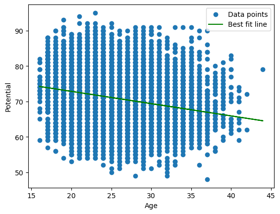

```python
# Write your own code

model = smf.ols(formula = 'Potential ~ Age', data = fifa)
results = model.fit()

b_list = results.params
print(b_list)

fifa["p_estimated"] = b_list[0] + b_list[1] * fifa["Age"]

plt.scatter(x = fifa["Age"],y = fifa["Potential"])
plt.plot(fifa["Age"],fifa["p_estimated"], color = 'green')
plt.xlabel("Age")
plt.ylabel("Potential")
plt.legend(labels = ["Data points", "Best fit line"])
plt.show()
```

(e) Split a dataset into subsets

- Store the total number of rows of the dataset in a variable called `n`
- Create a new variable called `random_var` drawn from a  
  uniform distribution between 0 and 1 with size `n`
- Use .query() to subset all observations with `random_var <0.5`.  
  store it in a new dataset called "data0"
- Use .query() to subset all observations with `random_var >= 0.5`.  
  store it in a new dataset called "data1"

[HINT: See Lecture 2 for how to generate a uniform random variable]

```python
# Write your own code

n = len(fifa)

random_var = np.random.uniform(low=0, high=1, size=n)

random_var = fifa["random_var"]

data0 = fifa.query("random_var < 0.5")
data1 = fifa.query("random_var >= 0.5")
```

[output not shown]

(f) Create two overlapping histogram plots

- This question requires the two datasets you created in (e)
- Display the distribution of "Age" for "data0" and "data1" using  
  `plt.hist()`
- You will need to label the axes, and the title
- To get full points, plot the histograms with the option `alpha = 0.5`, e.g.  
  `plt.hist(x = ..., alpha = 0.5)`  
  Make sure to substitute the corresponding "x" vector instead of `...`  
  (The alpha option sets the transparency of the histogram )

Note: The goal of this question is to illustrate that random  
assignment produces very similar distributions between two groups

```python
# Write your own code

list_data = [data0, data1]

for data in list_data:
    plt.hist(fifa['Age'], alpha=0.5)

plt.title('Age Subset by Data')
plt.xlabel('Age')
plt.ylabel('Frequency')
plt.legend(labels = list_data,
           title  = "Age")
plt.show()
```

[output not shown]